# Gene ontology (GO) analysis

John Blischak

**Last updated:** 2015-10-22

**Code version:** 044491cd5df4302bbdcf97ec1313fa184fc31516

```r
library("knitr")
opts_chunk$set(fig.align = "center", fig.width = 10)
```

## Setup

Load packages.

```r
library("topGO")
```

```r
library("biomaRt")
library("edgeR")
library("tidyr")
library("ggplot2")
theme_set(theme_bw(base_size = 12))
```

Import the filtered counts matrix.

```r
counts <- read.table("../../data/mouse/counts-matrix-filtered.txt",
                     header = TRUE)
dim(counts)
```

```
## [1] 13738     6
```

```r
head(counts)
```

```
##                    DMSO.REP1 DMSO.REP2 DMSO.REP3 RA.REP1 RA.REP2 RA.REP3
## ENSMUSG00000033845      3312      2890      2922    2981     772    1627
## ENSMUSG00000025903      1837      1789      1459    1348     409     881
## ENSMUSG00000033813       706       675       607     580     132     376
## ENSMUSG00000002459         8        17        15      43      13      48
## ENSMUSG00000033793      1612      1467      1390    1566     417    1081
## ENSMUSG00000025907      1473      1437      1253    1665     556    1167
```

Calculate log cpm.

```r
normalized_lib_sizes <- calcNormFactors(counts)
log_cpm <- cpm(counts, log = TRUE,
                lib.size = colSums(counts) * normalized_lib_sizes)
```

Import the DE results.

```r
de_results <- read.table("../../data/mouse/de-results.txt",
                         header = TRUE)
head(de_results)
```

```
##                          logFC   logCPM       PValue          FDR    de
## ENSMUSG00000033845 -0.13449462 7.535947 3.402753e-01 4.713826e-01 FALSE
## ENSMUSG00000025903 -0.27935785 6.625184 3.944787e-02 8.981354e-02 FALSE
## ENSMUSG00000033813 -0.28073406 5.271903 1.329561e-02 3.736042e-02  TRUE
## ENSMUSG00000002459  1.98438205 1.091352 8.360234e-09 1.242997e-07  TRUE
## ENSMUSG00000033793  0.07886065 6.612570 4.574341e-01 5.857344e-01 FALSE
## ENSMUSG00000025907  0.39736543 6.682437 4.430506e-03 1.520137e-02  TRUE
```

## Gene ontology analysis with topGO

Use topGO for GO analysis. It accounts for the nested graph structure of GO terms to prune the number of GO categories tested ([Alexa et al. 2006](http://www.ncbi.nlm.nih.gov/pubmed/16606683)). Essentially, it decreases the redundancy of the results.

First create the gene universe. This is all the genes tested for differential expression assigned a 1 for differentially expressed and 0 if not.

```r
gene_universe <- as.numeric(de_results$de)
gene_universe <- factor(gene_universe)
names(gene_universe) <- rownames(de_results)
head(gene_universe)
```

```
## ENSMUSG00000033845 ENSMUSG00000025903 ENSMUSG00000033813
##                  0                  0                  1
## ENSMUSG00000002459 ENSMUSG00000033793 ENSMUSG00000025907
##                  1                  0                  1
## Levels: 0 1
```

Create the topGO data object. Only consider “Biological Process” categories and use the Mouse Ensembl database for annotation.

```r
go_data <- new("topGOdata",
               ontology = "BP",
               allGenes = gene_universe,
               nodeSize = 5,
               annotationFun = annFUN.org,
               mapping = "org.Mm.eg",
               ID = "ensembl")
```

```
##
## Building most specific GOs .....
```

```
##  ( 9170 GO terms found. )
##
## Build GO DAG topology .......... ( 12663 GO terms and 30627 relations. )
##
## Annotating nodes ............... ( 13068 genes annotated to the GO terms. )
```

Use the weight01 algorithm and score the tests with Fisher’s exact test.

```r
go_test <- runTest(go_data, algorithm = "weight01", statistic = "fisher")
```

```
##
##           -- Weight01 Algorithm --
##
##       the algorithm is scoring 6650 nontrivial nodes
##       parameters:
##           test statistic:  fisher
##
##   Level 18:  1 nodes to be scored    (0 eliminated genes)
##
##   Level 17:  10 nodes to be scored   (0 eliminated genes)
##
##   Level 16:  27 nodes to be scored   (10 eliminated genes)
##
##   Level 15:  64 nodes to be scored   (64 eliminated genes)
##
##   Level 14:  149 nodes to be scored  (212 eliminated genes)
##
##   Level 13:  261 nodes to be scored  (576 eliminated genes)
##
##   Level 12:  404 nodes to be scored  (1360 eliminated genes)
##
##   Level 11:  627 nodes to be scored  (3038 eliminated genes)
##
##   Level 10:  798 nodes to be scored  (4129 eliminated genes)
##
##   Level 9:   968 nodes to be scored  (5796 eliminated genes)
##
##   Level 8:   951 nodes to be scored  (7080 eliminated genes)
##
##   Level 7:   904 nodes to be scored  (8196 eliminated genes)
##
##   Level 6:   714 nodes to be scored  (9062 eliminated genes)
##
##   Level 5:   464 nodes to be scored  (9673 eliminated genes)
##
##   Level 4:   224 nodes to be scored  (10209 eliminated genes)
##
##   Level 3:   61 nodes to be scored   (10404 eliminated genes)
##
##   Level 2:   22 nodes to be scored   (10601 eliminated genes)
##
##   Level 1:   1 nodes to be scored    (10667 eliminated genes)
```

Keep the results with a Fisher’s exact test p-value < 0.01.

```r
go_table <- GenTable(go_data, weightFisher = go_test,
                     orderBy = "weightFisher", ranksOf = "weightFisher",
                     topNodes = sum(score(go_test) < .01))
head(go_table)
```

```
##        GO.ID                                        Term Annotated
## 1 GO:0051290               protein heterotetramerization        35
## 2 GO:0030325                   adrenal gland development        14
## 3 GO:0030501 positive regulation of bone mineralizati...        23
## 4 GO:0010951 negative regulation of endopeptidase act...       110
## 5 GO:0051897 positive regulation of protein kinase B ...        55
## 6 GO:0007156 homophilic cell adhesion via plasma memb...        47
##   Significant Expected weightFisher
## 1          26    13.31      1.4e-05
## 2          13     5.32      3.1e-05
## 3          18     8.74      9.9e-05
## 4          57    41.82      0.00016
## 5          34    20.91      0.00029
## 6          30    17.87      0.00029
```

There are 101 significant results.

Reassuringly, there are many categories expected for a stem cell differentiating into neuronal precursors in response to treatment with retinoic acid.

```r
go_table[grep("retinoic", go_table$Term), ]
```

```
##         GO.ID                            Term Annotated Significant
## 32 GO:0042573 retinoic acid metabolic process         9           8
##    Expected weightFisher
## 32     3.42      0.00259
```

```r
go_table[grep("stem", go_table$Term), ]
```

```
##         GO.ID                                   Term Annotated Significant
## 46 GO:0001501            skeletal system development       323         163
## 61 GO:0048485 sympathetic nervous system development        13          12
## 65 GO:0035019          somatic stem cell maintenance        39          23
##    Expected weightFisher
## 46   122.79      0.00328
## 61     4.94      0.00609
## 65    14.83      0.00630
```

```r
go_table[grep("differentiation", go_table$Term), ]
```

```
##         GO.ID                 Term Annotated Significant Expected
## 52 GO:0030154 cell differentiation      2438        1111   926.84
##    weightFisher
## 52      0.00415
```

```r
go_table[grep("neur", go_table$Term), ]
```

```
##         GO.ID                                        Term Annotated
## 22 GO:0001764                            neuron migration       103
## 55 GO:0043525 positive regulation of neuron apoptotic ...        49
## 75 GO:0043524 negative regulation of neuron apoptotic ...       111
## 84 GO:0021785          branchiomotor neuron axon guidance         5
## 89 GO:0045213 neurotransmitter receptor metabolic proc...         5
##    Significant Expected weightFisher
## 22          53    39.16      0.00138
## 55          28    18.63      0.00501
## 75          55    42.20      0.00770
## 84           5     1.90      0.00793
## 89           5     1.90      0.00793
```

```r
go_table[grep("nerv", go_table$Term), ]
```

```
##         GO.ID                                   Term Annotated Significant
## 17 GO:0021612   facial nerve structural organization         7           7
## 61 GO:0048485 sympathetic nervous system development        13          12
##    Expected weightFisher
## 17     2.66      0.00114
## 61     4.94      0.00609
```

Investigate the RA genes.

```r
go_id_ra <- go_table[grep("retinoic", go_table$Term), "GO.ID"]
go_genes_ra <- genesInTerm(go_data, go_id_ra)[[1]]
ensembl <- useMart(host = "sep2015.archive.ensembl.org",
                   biomart = "ENSEMBL_MART_ENSEMBL",
                   dataset = "mmusculus_gene_ensembl")
gene_info_ra <- getBM(attributes = c("ensembl_gene_id", "chromosome_name",
                                  "external_gene_name", "description"),
                      filter = "ensembl_gene_id",
                      values = go_genes_ra,
                      mart = ensembl)
stopifnot(go_genes_ra == gene_info_ra$ensembl_gene_id)
gene_info_ra
```

```
##      ensembl_gene_id chromosome_name external_gene_name
## 1 ENSMUSG00000004885               3             Crabp2
## 2 ENSMUSG00000013584               9            Aldh1a2
## 3 ENSMUSG00000015134               7            Aldh1a3
## 4 ENSMUSG00000021214              13            Akr1c18
## 5 ENSMUSG00000024987              19            Cyp26a1
## 6 ENSMUSG00000025921               1              Rdh10
## 7 ENSMUSG00000046402               9               Rbp1
## 8 ENSMUSG00000062432              19            Cyp26c1
## 9 ENSMUSG00000074207               3               Adh1
##                                                                                  description
## 1                cellular retinoic acid binding protein II [Source:MGI Symbol;Acc:MGI:88491]
## 2           aldehyde dehydrogenase family 1, subfamily A2 [Source:MGI Symbol;Acc:MGI:107928]
## 3          aldehyde dehydrogenase family 1, subfamily A3 [Source:MGI Symbol;Acc:MGI:1861722]
## 4               aldo-keto reductase family 1, member C18 [Source:MGI Symbol;Acc:MGI:2145420]
## 5 cytochrome P450, family 26, subfamily a, polypeptide 1 [Source:MGI Symbol;Acc:MGI:1096359]
## 6                   retinol dehydrogenase 10 (all-trans) [Source:MGI Symbol;Acc:MGI:1924238]
## 7                      retinol binding protein 1, cellular [Source:MGI Symbol;Acc:MGI:97876]
## 8 cytochrome P450, family 26, subfamily c, polypeptide 1 [Source:MGI Symbol;Acc:MGI:2679699]
## 9                        alcohol dehydrogenase 1 (class I) [Source:MGI Symbol;Acc:MGI:87921]
```

Visualize the RA genes.

```r
log_cpm_ra <- log_cpm[go_genes_ra, ]
log_cpm_ra <- data.frame(gene = rownames(log_cpm_ra), log_cpm_ra,
                         stringsAsFactors = FALSE)
log_cpm_ra_long <- gather(log_cpm_ra, key = "sample", value = "log_cpm", -gene)
log_cpm_ra_long <- separate(log_cpm_ra_long, col = sample,
                            into = c("treatment", "replicate"), sep = "\\.")
log_cpm_ra_long$gene <- factor(log_cpm_ra_long$gene,
                               levels = go_genes_ra[order(de_results[go_genes_ra, "logFC"])],
                               labels = gene_info_ra$external_gene_name[order(de_results[go_genes_ra, "logFC"])])
head(log_cpm_ra_long)
```

```
##      gene treatment replicate    log_cpm
## 1  Crabp2      DMSO      REP1  0.9054316
## 2 Aldh1a2      DMSO      REP1  2.8943198
## 3 Aldh1a3      DMSO      REP1  1.7813047
## 4 Akr1c18      DMSO      REP1  0.9920260
## 5 Cyp26a1      DMSO      REP1 -3.6971706
## 6   Rdh10      DMSO      REP1  3.0129666
```

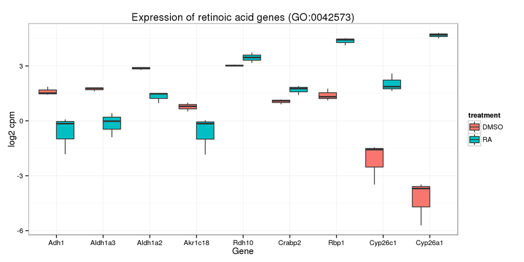

```r
ggplot(log_cpm_ra_long, aes(x = gene, y = log_cpm, fill = treatment)) +
  geom_boxplot() +
  labs(x = "Gene", y = "log2 cpm",
       title = sprintf("Expression of retinoic acid genes (%s)", go_id_ra))
```